# Kolins_M_Final_Project_Done

# Correlation Analyis

## Correlation Analyis Data Frame ( All )

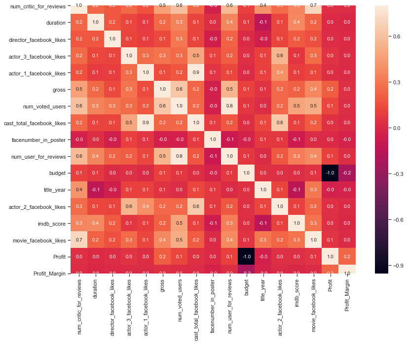

```python
plt.figure(figsize=(14,10))
sns.heatmap(df.corr(), vmax=.8, square=True, annot=True, fmt=".1f");
```

## Plotly Example

```python
import plotly.graph_objects as go
import plotly.express as px
```

```python
pf2 = df[df['Profit'] > 0 ].copy()
```

```python
px.scatter(pf2, x="imdb_score", y="gross", color="content_rating", hover_name='movie_title', size='Profit')
```

[interactive chart not shown]

# 1. Regression

## Dummy Variables

```python
df.info()
```

```
<class 'pandas.core.frame.DataFrame'>
Int64Index: 3779 entries, 0 to 5042
Data columns (total 26 columns):
director_name                3779 non-null object
num_critic_for_reviews       3779 non-null float64
duration                     3779 non-null float64
director_facebook_likes      3779 non-null float64
actor_3_facebook_likes       3779 non-null float64
actor_2_name                 3779 non-null object
actor_1_facebook_likes       3779 non-null float64
gross                        3779 non-null float64
genres                       3779 non-null object
actor_1_name                 3779 non-null object
movie_title                  3779 non-null object
num_voted_users              3779 non-null int64
cast_total_facebook_likes    3779 non-null int64
actor_3_name                 3779 non-null object
facenumber_in_poster         3779 non-null float64
plot_keywords                3779 non-null object
num_user_for_reviews         3779 non-null float64
country                      3779 non-null object
content_rating               3779 non-null object
budget                       3779 non-null float64
title_year                   3779 non-null float64
actor_2_facebook_likes       3779 non-null float64
imdb_score                   3779 non-null float64
movie_facebook_likes         3779 non-null int64
Profit                       3779 non-null float64
Profit_Margin                3779 non-null float64
dtypes: float64(14), int64(3), object(9)
memory usage: 957.1+ KB
```

All objects must be delt with

Content Rating - dummy creation

```python
df['content_rating'].unique()
```

```
array(['PG-13', 'PG', 'G', 'R', 'NC-17', 'Unrated'], dtype=object)
```

```python
df =  pd.get_dummies(df, columns=["content_rating"])

df.head(2)
```

|  | director_name | num_critic_for_reviews | duration | director_facebook_likes | actor_3_facebook_likes | actor_2_name | actor_1_facebook_likes | gross | genres | actor_1_name | movie_title | num_voted_users | cast_total_facebook_likes | actor_3_name | facenumber_in_poster | plot_keywords | num_user_for_reviews | country | budget | title_year | actor_2_facebook_likes | imdb_score | movie_facebook_likes | Profit | Profit_Margin | content_rating_G | content_rating_NC-17 | content_rating_PG | content_rating_PG-13 | … |
| --- | --- | --- | --- | --- | --- | --- | --- | --- | --- | --- | --- | --- | --- | --- | --- | --- | --- | --- | --- | --- | --- | --- | --- | --- | --- | --- | --- | --- | --- | --- |
| 0 | James Cameron | 723.000 | 178.000 | 0.000 | 855.000 | Joel David Moore | 1000.000 | 760505847.000 | Action\|Adventure\|Fantasy\|Sci-Fi | CCH Pounder | Avatar | 886204 | 4834 | Wes Studi | 0.000 | avatar\|future\|marine\|native\|paraplegic | 3054.000 | USA | 237000000.000 | 2009.000 | 936.000 | 7.900 | 33000 | 523505847.000 | 0.688 | 0 | 0 | 0 | 1 | … |
| 1 | Gore Verbinski | 302.000 | 169.000 | 563.000 | 1000.000 | Orlando Bloom | 40000.000 | 309404152.000 | Action\|Adventure\|Fantasy | Johnny Depp | Pirates of the Caribbean: At World's End | 471220 | 48350 | Jack Davenport | 0.000 | goddess\|marriage ceremony\|marriage proposal\|pirate\|singapore | 1238.000 | USA | 300000000.000 | 2007.000 | 5000.000 | 7.100 | 0 | 9404152.000 | 0.030 | 0 | 0 | 0 | 1 | … |

## Declare X Variables & Y Variable

```python
y = df['imdb_score']
#X = teams[['lstat', 'ptratio', 'indus']]
X = df.drop(['imdb_score','director_name','actor_2_name','actor_1_name','movie_title','genres','actor_3_name','plot_keywords','country'], axis =1)
```

Dropped all object variables

## Learn Multiple Regression

```python
model1 = lm.LinearRegression()
model1.fit(X, y)
model1_y = model1.predict(X)
```

```python
print("mean square error: ", mean_squared_error(y, model1_y))
print("variance or r-squared: ", explained_variance_score(y, model1_y))
```

```
mean square error:  0.6911798250399639
variance or r-squared:  0.37708257956325053
```

```python
pd.DataFrame(list(zip(X.columns, np.transpose(model1.coef_))))
```

|  | 0 | 1 |
| --- | --- | --- |
| 0 | num_critic_for_reviews | 0.002 |
| 1 | duration | 0.010 |
| 2 | director_facebook_likes | 0.000 |
| 3 | actor_3_facebook_likes | 0.000 |
| 4 | actor_1_facebook_likes | 0.000 |
| 5 | gross | -0.000 |
| 6 | num_voted_users | 0.000 |
| 7 | cast_total_facebook_likes | -0.000 |
| 8 | facenumber_in_poster | -0.020 |
| 9 | num_user_for_reviews | -0.001 |
| 10 | budget | -0.000 |
| 11 | title_year | -0.020 |
| 12 | actor_2_facebook_likes | 0.000 |
| 13 | movie_facebook_likes | -0.000 |
| 14 | Profit | -0.000 |
| 15 | Profit_Margin | -0.000 |
| 16 | content_rating_G | 0.043 |
| 17 | content_rating_NC-17 | -0.152 |
| 18 | content_rating_PG | -0.109 |
| 19 | content_rating_PG-13 | -0.276 |
| 20 | content_rating_R | 0.012 |
| 21 | content_rating_Unrated | 0.483 |

```python
coef = ["%.3f" % i for i in model1.coef_]
xcolumns = [ i for i in X.columns ]
list(zip(xcolumns, coef))
```

```
[('num_critic_for_reviews', '0.002'),
 ('duration', '0.010'),
 ('director_facebook_likes', '0.000'),
 ('actor_3_facebook_likes', '0.000'),
 ('actor_1_facebook_likes', '0.000'),
 ('gross', '-0.000'),
 ('num_voted_users', '0.000'),
 ('cast_total_facebook_likes', '-0.000'),
 ('facenumber_in_poster', '-0.020'),
 ('num_user_for_reviews', '-0.001'),
 ('budget', '-0.000'),
 ('title_year', '-0.020'),
 ('actor_2_facebook_likes', '0.000'),
 ('movie_facebook_likes', '-0.000'),
 ('Profit', '-0.000'),
 ('Profit_Margin', '-0.000'),
 ('content_rating_G', '0.043'),
 ('content_rating_NC-17', '-0.152'),
 ('content_rating_PG', '-0.109'),
 ('content_rating_PG-13', '-0.276'),
 ('content_rating_R', '0.012'),
 ('content_rating_Unrated', '0.483')]
```

Takeaways

- Multiple Regression
  - R Score: .377
  - Most Important Feature: content_rating_unrated

## SKL Learn Multiple Regression

```python
from sklearn.model_selection import train_test_split
```

```python
#create two datasets from the origianl

# train data

# test data

X_train, X_test, y_train, y_test = train_test_split(X, y, test_size=0.3, random_state=42)
```

```python
print (len(df), len(X),len(y))
```

```
3779 3779 3779
```

```python
print (len(X_train), len(y_train), len(X_test),len(y_test))
```

```
2645 2645 1134 1134
```

```python
model1 = lm.LinearRegression()

model1.fit(X_train, y_train)
#built

pred_y = model1.predict(X_test)
```

```python
print("mean square error: ", mean_squared_error(y_test, pred_y))
print("variance or r-squared: ", explained_variance_score(y_test, pred_y))
```

```
mean square error:  0.7488293701006953
variance or r-squared:  0.3691464957859042
```

Takeaways

- Regression, SKL Learn
  - R Score: .369

## Regression Lasso

```python
model1 = linear_model.Lasso()
model1.fit(X, y)
model1_y = model1.predict(X)
```

```python
print('Coefficients: ', model1.coef_)
print("y-intercept ", model1.intercept_)
```

```
Coefficients:  [ 1.73508272e-03  8.77857187e-03  7.91962325e-06  6.47924581e-05
  7.03955771e-05 -1.81628853e-09  3.87891404e-06 -6.97132219e-05
 -0.00000000e+00 -5.12903703e-04 -2.92197140e-11 -8.19339056e-03
  7.26883936e-05 -1.67070072e-06  1.25187391e-11 -5.34927594e-06
  0.00000000e+00  0.00000000e+00  0.00000000e+00 -0.00000000e+00
  0.00000000e+00  0.00000000e+00]
y-intercept  21.551087165344295
```

```python
coef = ["%.3f" % i for i in model1.coef_]
xcolumns = [ i for i in X.columns ]
list(zip(xcolumns, coef))
```

```
[('num_critic_for_reviews', '0.002'),
 ('duration', '0.009'),
 ('director_facebook_likes', '0.000'),
 ('actor_3_facebook_likes', '0.000'),
 ('actor_1_facebook_likes', '0.000'),
 ('gross', '-0.000'),
 ('num_voted_users', '0.000'),
 ('cast_total_facebook_likes', '-0.000'),
 ('facenumber_in_poster', '-0.000'),
 ('num_user_for_reviews', '-0.001'),
 ('budget', '-0.000'),
 ('title_year', '-0.008'),
 ('actor_2_facebook_likes', '0.000'),
 ('movie_facebook_likes', '-0.000'),
 ('Profit', '0.000'),
 ('Profit_Margin', '-0.000'),
 ('content_rating_G', '0.000'),
 ('content_rating_NC-17', '0.000'),
 ('content_rating_PG', '0.000'),
 ('content_rating_PG-13', '-0.000'),
 ('content_rating_R', '0.000'),
 ('content_rating_Unrated', '0.000')]
```

```python
print("mean square error: ", mean_squared_error(y, model1_y))
print("variance or r-squared: ", explained_variance_score(y, model1_y))
```

```
mean square error:  0.7307147758537375
variance or r-squared:  0.34145218543740097
```

Takeaways

## Regression Ridge

```python
model2 = linear_model.Ridge()            #higher alpha (penality parameter), fewer predictors
model2.fit(X, y)
model2_y = model2.predict(X)
```

```python
print("mean square error: ", mean_squared_error(y, model2_y))
print("variance or r-squared: ", explained_variance_score(y, model2_y))
```

```
mean square error:  0.6911811714367825
variance or r-squared:  0.3770813661394745
```

Takeaways

- Ridge Regression
  - R Score: .377

## Feature Selection

### 2 Variables

```python
X_new = SelectKBest(f_regression, k=2).fit_transform(X, y)
```

```python
selector = SelectKBest(f_regression, k=2).fit(X, y)
idxs_selected = selector.get_support(indices=True)
print(idxs_selected)
```

```
[1 6]
```

```python
X.head()
```

|  | num_critic_for_reviews | duration | director_facebook_likes | actor_3_facebook_likes | actor_1_facebook_likes | gross | num_voted_users | cast_total_facebook_likes | facenumber_in_poster | num_user_for_reviews | budget | title_year | actor_2_facebook_likes | movie_facebook_likes | Profit | Profit_Margin | content_rating_G | content_rating_NC-17 | content_rating_PG | content_rating_PG-13 | content_rating_R | content_rating_Unrated |
| --- | --- | --- | --- | --- | --- | --- | --- | --- | --- | --- | --- | --- | --- | --- | --- | --- | --- | --- | --- | --- | --- | --- |
| 0 | 723.000 | 178.000 | 0.000 | 855.000 | 1000.000 | 760505847.000 | 886204 | 4834 | 0.000 | 3054.000 | 237000000.000 | 2009.000 | 936.000 | 33000 | 523505847.000 | 0.688 | 0 | 0 | 0 | 1 | 0 | 0 |
| 1 | 302.000 | 169.000 | 563.000 | 1000.000 | 40000.000 | 309404152.000 | 471220 | 48350 | 0.000 | 1238.000 | 300000000.000 | 2007.000 | 5000.000 | 0 | 9404152.000 | 0.030 | 0 | 0 | 0 | 1 | 0 | 0 |
| 2 | 602.000 | 148.000 | 0.000 | 161.000 | 11000.000 | 200074175.000 | 275868 | 11700 | 1.000 | 994.000 | 245000000.000 | 2015.000 | 393.000 | 85000 | -44925825.000 | -0.225 | 0 | 0 | 0 | 1 | 0 | 0 |
| 3 | 813.000 | 164.000 | 22000.000 | 23000.000 | 27000.000 | 448130642.000 | 1144337 | 106759 | 0.000 | 2701.000 | 250000000.000 | 2012.000 | 23000.000 | 164000 | 198130642.000 | 0.442 | 0 | 0 | 0 | 1 | 0 | 0 |
| 5 | 462.000 | 132.000 | 475.000 | 530.000 | 640.000 | 73058679.000 | 212204 | 1873 | 1.000 | 738.000 | 263700000.000 | 2012.000 | 632.000 | 24000 | -190641321.000 | -2.609 | 0 | 0 | 0 | 1 | 0 | 0 |

```python
model2 = lm.LinearRegression()
model2.fit(X_new, y)
model2_y = model2.predict(X_new)

print("mean square error: ", mean_squared_error(y, model2_y))
print("variance or r-squared: ", explained_variance_score(y, model2_y))
```

```
mean square error:  0.8028832058542915
variance or r-squared:  0.2764112646461787
```

Takeaways

- Multiple Regression Two Variables
  - R Score: .276
  - Most Important Feature: Duration/Number of voted users

### 3 Variables

```python
X_new = SelectKBest(f_regression, k=3).fit_transform(X, y)
```

```python
model3 = lm.LinearRegression()
model3.fit(X_new, y)
model3_y = model3.predict(X_new)

print("mean square error: ", mean_squared_error(y, model3_y))
print("variance or r-squared: ", explained_variance_score(y, model3_y))
```

```
mean square error:  0.7974994174238752
variance or r-squared:  0.2812633385634956
```

Takeaways

- Multiple Regression Three Variables
  - R Score: .281

## Recursive Feature Selection

```python
lr = lm.LinearRegression()
rfe = RFE(lr, n_features_to_select=2)
rfe_y = rfe.fit(X,y)

print("Features sorted by their rank:")
print(sorted(zip([x for x in rfe.ranking_], X.columns)))
```

[output not shown]

## RandormForestRegressor

```python
from sklearn.ensemble import RandomForestRegressor
from sklearn.datasets import make_regression


regr = RandomForestRegressor(n_estimators=100, random_state=0)
regr.fit(X, y)
regr_predicted = regr.predict(X)

print("mean square error: ", mean_squared_error(y, regr_predicted))
print("variance or r-squared: ", explained_variance_score(y, regr_predicted))
```

```
mean square error:  0.06776609050013234
variance or r-squared:  0.9389767065153957
```

```python
sorted(zip(regr.feature_importances_, X.columns))
```

```
[(0.00029937028762758833, 'content_rating_Unrated'),
 (0.0007297740480039254, 'content_rating_NC-17'),
 (0.0038676185599188944, 'content_rating_G'),
 (0.003962832692064488, 'content_rating_PG'),
 (0.004442461257879768, 'content_rating_R'),
 (0.009186682392999896, 'content_rating_PG-13'),
 (0.016327308671340367, 'facenumber_in_poster'),
 (0.020632467030040208, 'actor_1_facebook_likes'),
 (0.023921937621447537, 'Profit'),
 (0.025099074684484454, 'movie_facebook_likes'),
 (0.02563031260035008, 'cast_total_facebook_likes'),
 (0.025632006151764024, 'actor_2_facebook_likes'),
 (0.02709541862941405, 'Profit_Margin'),
 (0.031597362124481804, 'director_facebook_likes'),
 (0.035851427748197856, 'actor_3_facebook_likes'),
 (0.03922711894215044, 'title_year'),
 (0.04387392747663863, 'num_critic_for_reviews'),
 (0.05485197217976068, 'gross'),
 (0.06392634942525272, 'num_user_for_reviews'),
 (0.10709794601401727, 'budget'),
 (0.11029859220034728, 'duration'),
 (0.32644803926181815, 'num_voted_users')]
```

Takeaways

- Random Forest Regressor
  - R Score: .938
  - Most Important Feature: number of voted users/duration/budget

## RandormForestRegressor Limited Selection

```python
y = df['imdb_score']
#X = teams[['lstat', 'ptratio', 'indus']]
X = df[['num_voted_users','duration','budget','num_user_for_reviews','gross']]


regr = RandomForestRegressor(n_estimators=100, random_state=0)
regr.fit(X, y)
regr_predicted = regr.predict(X)

print("mean square error: ", mean_squared_error(y, regr_predicted))
print("variance or r-squared: ", explained_variance_score(y, regr_predicted))
```

```
mean square error:  0.07585567795713156
variance or r-squared:  0.9316819874214622
```

```python
sorted(zip(regr.feature_importances_, X.columns))
```

```
[(0.12637751143077025, 'num_user_for_reviews'),
 (0.13960008251366113, 'gross'),
 (0.16002160543391677, 'duration'),
 (0.16981825511541623, 'budget'),
 (0.4041825455062355, 'num_voted_users')]
```

Takeaways

- Ramdom Forest 5 Variables
  - R Score: .9316
  - Most Important Feature: number of voted users/duration/budget

# 2. Classification

## Import Data

```python
dfca=pd.read_csv('movie.csv')
dfca.head()
```

|  | color | director_name | num_critic_for_reviews | duration | director_facebook_likes | actor_3_facebook_likes | actor_2_name | actor_1_facebook_likes | gross | genres | actor_1_name | movie_title | num_voted_users | cast_total_facebook_likes | actor_3_name | facenumber_in_poster | plot_keywords | movie_imdb_link | num_user_for_reviews | language | country | content_rating | budget | title_year | actor_2_facebook_likes | imdb_score | aspect_ratio | movie_facebook_likes |
| --- | --- | --- | --- | --- | --- | --- | --- | --- | --- | --- | --- | --- | --- | --- | --- | --- | --- | --- | --- | --- | --- | --- | --- | --- | --- | --- | --- | --- |
| 0 | Color | James Cameron | 723.000 | 178.000 | 0.000 | 855.000 | Joel David Moore | 1000.000 | 760505847.000 | Action\|Adventure\|Fantasy\|Sci-Fi | CCH Pounder | Avatar | 886204 | 4834 | Wes Studi | 0.000 | avatar\|future\|marine\|native\|paraplegic | http://www.imdb.com/title/tt0499549/?ref_=fn_tt_tt_1 | 3054.000 | English | USA | PG-13 | 237000000.000 | 2009.000 | 936.000 | 7.900 | 1.780 | 33000 |
| 1 | Color | Gore Verbinski | 302.000 | 169.000 | 563.000 | 1000.000 | Orlando Bloom | 40000.000 | 309404152.000 | Action\|Adventure\|Fantasy | Johnny Depp | Pirates of the Caribbean: At World's End | 471220 | 48350 | Jack Davenport | 0.000 | goddess\|marriage ceremony\|marriage proposal\|pirate\|singapore | http://www.imdb.com/title/tt0449088/?ref_=fn_tt_tt_1 | 1238.000 | English | USA | PG-13 | 300000000.000 | 2007.000 | 5000.000 | 7.100 | 2.350 | 0 |
| 2 | Color | Sam Mendes | 602.000 | 148.000 | 0.000 | 161.000 | Rory Kinnear | 11000.000 | 200074175.000 | Action\|Adventure\|Thriller | Christoph Waltz | Spectre | 275868 | 11700 | Stephanie Sigman | 1.000 | bomb\|espionage\|sequel\|spy\|terrorist | http://www.imdb.com/title/tt2379713/?ref_=fn_tt_tt_1 | 994.000 | English | UK | PG-13 | 245000000.000 | 2015.000 | 393.000 | 6.800 | 2.350 | 85000 |
| 3 | Color | Christopher Nolan | 813.000 | 164.000 | 22000.000 | 23000.000 | Christian Bale | 27000.000 | 448130642.000 | Action\|Thriller | Tom Hardy | The Dark Knight Rises | 1144337 | 106759 | Joseph Gordon-Levitt | 0.000 | deception\|imprisonment\|lawlessness\|police officer\|terrorist plot | http://www.imdb.com/title/tt1345836/?ref_=fn_tt_tt_1 | 2701.000 | English | USA | PG-13 | 250000000.000 | 2012.000 | 23000.000 | 8.500 | 2.350 | 164000 |
| 4 | NaN | Doug Walker | nan | nan | 131.000 | nan | Rob Walker | 131.000 | nan | Documentary | Doug Walker | Star Wars: Episode VII - The Force Awakens | 8 | 143 | NaN | 0.000 | NaN | http://www.imdb.com/title/tt5289954/?ref_=fn_tt_tt_1 | nan | NaN | NaN | NaN | nan | nan | 12.000 | 7.100 | nan | 0 |

## Binning

```python
op_labels = ['bad', 'ok', 'good','excellent']
category = [0.,4.,6.,8.,10.]
df['imdb_labels'] = pd.cut(df['imdb_score'], labels=op_labels, bins=category)
```

Create catagorical bins for IMDB scores for classification

df = pd.get_dummies(df, columns=["imdb_labels"]) df.head(2)

```python
df.columns
```

```
Index(['director_name', 'num_critic_for_reviews', 'duration',
       'director_facebook_likes', 'actor_3_facebook_likes', 'actor_2_name',
       'actor_1_facebook_likes', 'gross', 'genres', 'actor_1_name',
       'movie_title', 'num_voted_users', 'cast_total_facebook_likes',
       'actor_3_name', 'facenumber_in_poster', 'plot_keywords',
       'num_user_for_reviews', 'country', 'budget', 'title_year',
       'actor_2_facebook_likes', 'imdb_score', 'movie_facebook_likes',
       'Profit', 'Profit_Margin', 'content_rating_G', 'content_rating_NC-17',
       'content_rating_PG', 'content_rating_PG-13', 'content_rating_R',
       'content_rating_Unrated', 'imdb_labels'],
      dtype='object')
```

```python
df.to_csv("data/imdbdataClass.csv")
```

## ANOVA Testing

```python
bad = df[df['imdb_labels'] == 'bad']['duration']
excellent = df[df['imdb_labels'] == 'excellent']['duration']
good = df[df['imdb_labels'] == 'good']['duration']
ok = df[df['imdb_labels'] == 'ok']['duration']

f_val, p_val = stats.f_oneway(bad, excellent, good, ok)

print("One-way ANOVA P =", p_val)
```

```
One-way ANOVA P = 1.2599037186792591e-96
```

```python
from statsmodels.stats.multicomp import pairwise_tukeyhsd

print(pairwise_tukeyhsd(df['duration'], df['imdb_labels']))
```

```
    Multiple Comparison of Means - Tukey HSD, FWER=0.05
============================================================
  group1    group2  meandiff p-adj   lower    upper   reject
------------------------------------------------------------
      bad excellent  39.8614  0.001  32.7379  46.9848   True
      bad      good  17.4494  0.001  11.7128   23.186   True
      bad        ok   6.1504 0.0361   0.2733  12.0276   True
excellent      good  -22.412  0.001 -26.9145 -17.9094   True
excellent        ok -33.7109  0.001 -38.3912 -29.0307   True
     good        ok -11.2989  0.001 -13.3163  -9.2816   True
------------------------------------------------------------
```

## Declare X Variables & Y Variable

```python
y = df['imdb_labels']
#X = teams[['lstat', 'ptratio', 'indus']]
X = df.drop(['imdb_labels','imdb_score','director_name','actor_2_name',
             'actor_1_name','movie_title','genres','actor_3_name',
             'plot_keywords','country'], axis =1)
```

```python
X.columns
```

```
Index(['num_critic_for_reviews', 'duration', 'director_facebook_likes',
       'actor_3_facebook_likes', 'actor_1_facebook_likes', 'gross',
       'num_voted_users', 'cast_total_facebook_likes', 'facenumber_in_poster',
       'num_user_for_reviews', 'budget', 'title_year',
       'actor_2_facebook_likes', 'movie_facebook_likes', 'Profit',
       'Profit_Margin', 'content_rating_G', 'content_rating_NC-17',
       'content_rating_PG', 'content_rating_PG-13', 'content_rating_R',
       'content_rating_Unrated'],
      dtype='object')
```

```python
pd.set_option('display.max_colwidth', -1)
pd.set_option('display.max_columns', None)
```

```python
X.head(2)
```

|  | num_critic_for_reviews | duration | director_facebook_likes | actor_3_facebook_likes | actor_1_facebook_likes | gross | num_voted_users | cast_total_facebook_likes | facenumber_in_poster | num_user_for_reviews | budget | title_year | actor_2_facebook_likes | movie_facebook_likes | Profit | Profit_Margin | content_rating_G | content_rating_NC-17 | content_rating_PG | content_rating_PG-13 | content_rating_R | content_rating_Unrated |
| --- | --- | --- | --- | --- | --- | --- | --- | --- | --- | --- | --- | --- | --- | --- | --- | --- | --- | --- | --- | --- | --- | --- |
| 0 | 723.000 | 178.000 | 0.000 | 855.000 | 1000.000 | 760505847.000 | 886204 | 4834 | 0.000 | 3054.000 | 237000000.000 | 2009.000 | 936.000 | 33000 | 523505847.000 | 0.688 | 0 | 0 | 0 | 1 | 0 | 0 |
| 1 | 302.000 | 169.000 | 563.000 | 1000.000 | 40000.000 | 309404152.000 | 471220 | 48350 | 0.000 | 1238.000 | 300000000.000 | 2007.000 | 5000.000 | 0 | 9404152.000 | 0.030 | 0 | 0 | 0 | 1 | 0 | 0 |

```python
X.isnull().sum()
```

```
num_critic_for_reviews       0
duration                     0
director_facebook_likes      0
actor_3_facebook_likes       0
actor_1_facebook_likes       0
gross                        0
num_voted_users              0
cast_total_facebook_likes    0
facenumber_in_poster         0
num_user_for_reviews         0
budget                       0
title_year                   0
actor_2_facebook_likes       0
movie_facebook_likes         0
Profit                       0
Profit_Margin                0
content_rating_G             0
content_rating_NC-17         0
content_rating_PG            0
content_rating_PG-13         0
content_rating_R             0
content_rating_Unrated       0
dtype: int64
```

## Decision Tree

```python
# split validation
X_train, X_test, y_train, y_test = train_test_split(X, y, test_size=0.3, random_state=42)

# Initialize DecisionTreeClassifier() ... name your decision model "dt"
dt = DecisionTreeClassifier()


# Train a decision tree model
dt = dt.fit(X_train,y_train)
```

```python
#Model evaluation
# http://scikit-learn.org/stable/modules/model_evaluation.html
print(metrics.accuracy_score(y_test, dt.predict(X_test)))
print("--------------------------------------------------------")
print(metrics.confusion_matrix(y_test, dt.predict(X_test)))
print("--------------------------------------------------------")
print(metrics.classification_report(y_test, dt.predict(X_test)))
print("--------------------------------------------------------")
#print(metrics.roc_auc_score(y_test, dt.predict(X_test)))

# y-test is the acual y value in the testing dataset
# dt.predict(X_test) is the predicted y value generated by your model
# If they are same, we can say your model is accurate.
```

```
0.6754850088183422
--------------------------------------------------------
[[  6   0  10  12]
 [  0  33  21   0]
 [  7  26 558 150]
 [ 18   0 124 169]]
--------------------------------------------------------
              precision    recall  f1-score   support

         bad       0.19      0.21      0.20        28
   excellent       0.56      0.61      0.58        54
        good       0.78      0.75      0.77       741
          ok       0.51      0.54      0.53       311

    accuracy                           0.68      1134
   macro avg       0.51      0.53      0.52      1134
weighted avg       0.68      0.68      0.68      1134

--------------------------------------------------------
```

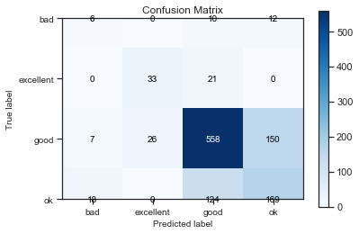

```python
import scikitplot as skplt

skplt.metrics.plot_confusion_matrix(y_true=np.array(y_test), y_pred=dt.predict(X_test))
plt.show()
```

```python
from graphviz import Source
from sklearn import tree
Source( tree.export_graphviz(dt, out_file=None, feature_names=X.columns))
```

[figure not shown]

Accuracy = 67%

Takeaways

- Decision Tree
  - R Score: .675

## Random Forest Classifier

```python
from sklearn.ensemble import RandomForestClassifier

clf = RandomForestClassifier(n_estimators=20)    #building 20 decision trees
clf=clf.fit(X_train, y_train)
clf.score(X_test, y_test)
```

```
0.7522045855379189
```

```python
# generate evaluation metrics
print(metrics.accuracy_score(y_test, clf.predict(X_test))) #overall accuracy
print(metrics.confusion_matrix(y_test, clf.predict(X_test)))
print(metrics.classification_report(y_test, clf.predict(X_test)))
```

```
0.7522045855379189
[[  0   0  11  17]
 [  0  26  28   0]
 [  0   5 688  48]
 [  0   0 172 139]]
              precision    recall  f1-score   support

         bad       0.00      0.00      0.00        28
   excellent       0.84      0.48      0.61        54
        good       0.77      0.93      0.84       741
          ok       0.68      0.45      0.54       311

    accuracy                           0.75      1134
   macro avg       0.57      0.46      0.50      1134
weighted avg       0.73      0.75      0.73      1134
```

Accuracy = 75%

Takeaways

## Feature Importance

```python
# another method
pd.DataFrame(clf.feature_importances_, index = X.columns,
                                    columns=['importance']).sort_values('importance', ascending=False)
```

|  | importance |
| --- | --- |
| num_voted_users | 0.134 |
| duration | 0.088 |
| gross | 0.065 |
| budget | 0.064 |
| Profit | 0.064 |
| num_user_for_reviews | 0.063 |
| num_critic_for_reviews | 0.062 |
| Profit_Margin | 0.057 |
| title_year | 0.053 |
| director_facebook_likes | 0.052 |
| cast_total_facebook_likes | 0.052 |
| actor_3_facebook_likes | 0.050 |
| movie_facebook_likes | 0.049 |
| actor_2_facebook_likes | 0.047 |
| actor_1_facebook_likes | 0.046 |
| facenumber_in_poster | 0.026 |
| content_rating_PG-13 | 0.009 |
| content_rating_R | 0.009 |
| content_rating_PG | 0.006 |
| content_rating_G | 0.003 |
| content_rating_Unrated | 0.002 |
| content_rating_NC-17 | 0.000 |

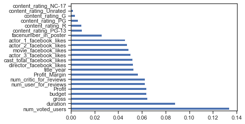

```python
pd.DataFrame(clf.feature_importances_, index = X.columns,
                                    columns=['importance']).sort_values('importance', ascending=False).plot(kind='barh',
                                                                                                            legend=None);
```

Takeaways

```python
#Predict class probabilities for X
clf.predict_proba(X_test)
# 1st value: the probability of NO
# 2nd value: the probability of YES (2nd heart attack)
```

```
array([[0.05, 0.3 , 0.65, 0.  ],
       [0.  , 0.  , 0.55, 0.45],
       [0.  , 0.  , 0.65, 0.35],
       ...,
       [0.  , 0.45, 0.5 , 0.05],
       [0.1 , 0.2 , 0.65, 0.05],
       [0.05, 0.  , 0.7 , 0.25]])
```

## Support Vector Machine (SVM)

```python
svm = SVC(gamma='scale', probability=True)
svm.fit(X_train, y_train)
```

```
SVC(C=1.0, cache_size=200, class_weight=None, coef0=0.0,
    decision_function_shape='ovr', degree=3, gamma='scale', kernel='rbf',
    max_iter=-1, probability=True, random_state=None, shrinking=True, tol=0.001,
    verbose=False)
```

```python
#Model evaluation
# http://scikit-learn.org/stable/modules/model_evaluation.html
print(metrics.accuracy_score(y_test, svm.predict(X_test)))
print("--------------------------------------------------------")
print(metrics.confusion_matrix(y_test, svm.predict(X_test)))
print("--------------------------------------------------------")
print(metrics.classification_report(y_test, svm.predict(X_test)))
print("--------------------------------------------------------")
```

```
0.6534391534391535
--------------------------------------------------------
[[  0   0  28   0]
 [  0   0  54   0]
 [  0   0 741   0]
 [  0   1 310   0]]
--------------------------------------------------------
              precision    recall  f1-score   support

         bad       0.00      0.00      0.00        28
   excellent       0.00      0.00      0.00        54
        good       0.65      1.00      0.79       741
          ok       0.00      0.00      0.00       311

    accuracy                           0.65      1134
   macro avg       0.16      0.25      0.20      1134
weighted avg       0.43      0.65      0.52      1134

--------------------------------------------------------
```

```python
# 10-fold cross-validation
svm = SVC(gamma='auto')

scores = cross_val_score(svm, X, y, scoring='accuracy', cv=10)
print(scores)
print(scores.mean())
```

```
[0.65699208 0.65171504 0.65171504 0.65699208 0.65699208 0.66402116
 0.65782493 0.65517241 0.65957447 0.66755319]
0.6578552503529564
```

Accuracy = 65%

Takeaways

## Logistic regression

```python
X_train, X_test, y_train, y_test = train_test_split(X, y, test_size=0.3, random_state=0)
lr = LogisticRegression(solver='lbfgs', max_iter=500,multi_class='auto')
lr.fit(X_train, y_train)
```

```
LogisticRegression(C=1.0, class_weight=None, dual=False, fit_intercept=True,
                   intercept_scaling=1, l1_ratio=None, max_iter=500,
                   multi_class='auto', n_jobs=None, penalty='l2',
                   random_state=None, solver='lbfgs', tol=0.0001, verbose=0,
                   warm_start=False)
```

```python
print(metrics.accuracy_score(y_test, lr.predict(X_test)))
print(metrics.confusion_matrix(y_test, lr.predict(X_test)))
print(metrics.classification_report(y_test, lr.predict(X_test)))
```

```
0.6516754850088183
[[  0   0  21   0]
 [  0  27  27   0]
 [  0  36 667  33]
 [  0   1 277  45]]
              precision    recall  f1-score   support

         bad       0.00      0.00      0.00        21
   excellent       0.42      0.50      0.46        54
        good       0.67      0.91      0.77       736
          ok       0.58      0.14      0.22       323

    accuracy                           0.65      1134
   macro avg       0.42      0.39      0.36      1134
weighted avg       0.62      0.65      0.59      1134
```

```python
# generate class probabilities
probs = lr.predict_proba(X_test)
print(probs)
#1st column: probability of NOT having 2nd heart attack
#2nd column: probabiility of having 2nd heart attack
```

```
[[2.79033251e-06 1.65146761e-02 7.30264340e-01 2.53218194e-01]
 [9.21809496e-04 3.03069787e-01 5.74136777e-01 1.21871627e-01]
 [1.95692590e-01 2.23197635e-01 3.02549865e-01 2.78559910e-01]
 ...
 [5.56460548e-02 2.18773071e-02 5.77944838e-01 3.44531800e-01]
 [1.78477741e-01 1.58585218e-01 3.35363344e-01 3.27573697e-01]
 [1.94762542e-03 1.23678547e-01 6.83899659e-01 1.90474168e-01]]
```

Accuracy = 65%

Takeaways

## k-Nearest Neighbor (KNN)

```python
# split validation
X_train, X_test, y_train, y_test = train_test_split(X, y, test_size=0.3, random_state=42)

# Initialize DecisionTreeClassifier() ... name your decision model "dt"
# IQ is at zero currently
knn = KNeighborsClassifier()

#Build Model
# Train a decision tree model
knn = knn.fit(X_train,y_train)
knn
```

```
KNeighborsClassifier(algorithm='auto', leaf_size=30, metric='minkowski',
                     metric_params=None, n_jobs=None, n_neighbors=5, p=2,
                     weights='uniform')
```

```python
#Model evaluation
# http://scikit-learn.org/stable/modules/model_evaluation.html
#Model evaluation
# http://scikit-learn.org/stable/modules/model_evaluation.html
print(metrics.accuracy_score(y_test, knn.predict(X_test)))
print("--------------------------------------------------------")
print(metrics.confusion_matrix(y_test, knn.predict(X_test)))
print("--------------------------------------------------------")
print(metrics.classification_report(y_test, knn.predict(X_test)))
print("--------------------------------------------------------")

# y-test is the acual y value in the testing dataset
# dt.predict(X_test) is the predicted y value generated by your model
# If they are same, we can say your model is accurate.
```

```
0.5987654320987654
--------------------------------------------------------
[[  0   0  20   8]
 [  0   5  46   3]
 [  4   9 606 122]
 [  1   2 240  68]]
--------------------------------------------------------
              precision    recall  f1-score   support

         bad       0.00      0.00      0.00        28
   excellent       0.31      0.09      0.14        54
        good       0.66      0.82      0.73       741
          ok       0.34      0.22      0.27       311

    accuracy                           0.60      1134
   macro avg       0.33      0.28      0.29      1134
weighted avg       0.54      0.60      0.56      1134

--------------------------------------------------------
```

Takeaways

## GradientBoostingClassifier

```python
# split validation
X_train, X_test, y_train, y_test = train_test_split(X, y, test_size=0.3, random_state=0)

# initialize
gb = GradientBoostingClassifier(n_estimators=100, random_state=0)

# fit the model
gb.fit(X_train, y_train)
```

```
GradientBoostingClassifier(criterion='friedman_mse', init=None,
                           learning_rate=0.1, loss='deviance', max_depth=3,
                           max_features=None, max_leaf_nodes=None,
                           min_impurity_decrease=0.0, min_impurity_split=None,
                           min_samples_leaf=1, min_samples_split=2,
                           min_weight_fraction_leaf=0.0, n_estimators=100,
                           n_iter_no_change=None, presort='auto',
                           random_state=0, subsample=1.0, tol=0.0001,
                           validation_fraction=0.1, verbose=0,
                           warm_start=False)
```

```python
#Model evaluation
# http://scikit-learn.org/stable/modules/model_evaluation.html
print(metrics.accuracy_score(y_test, gb.predict(X_test)))
print("--------------------------------------------------------")
print(metrics.confusion_matrix(y_test, gb.predict(X_test)))
print("--------------------------------------------------------")
print(metrics.classification_report(y_test, gb.predict(X_test)))
print("--------------------------------------------------------")


# y-test is the acual y value in the testing dataset
# gb.predict(X_test) is the predicted y value generated by your model
# If they are same, we can say your model is accurate.
```

```
0.7610229276895943
--------------------------------------------------------
[[  0   0   5  16]
 [  0  27  27   0]
 [  0   3 662  71]
 [  1   0 148 174]]
--------------------------------------------------------
              precision    recall  f1-score   support

         bad       0.00      0.00      0.00        21
   excellent       0.90      0.50      0.64        54
        good       0.79      0.90      0.84       736
          ok       0.67      0.54      0.60       323

    accuracy                           0.76      1134
   macro avg       0.59      0.48      0.52      1134
weighted avg       0.74      0.76      0.74      1134

--------------------------------------------------------
```

```python
# 10-fold cross-validation
scores = cross_val_score(gb, X, y, scoring='accuracy', cv=10)
print(scores)
print(scores.mean())
```

```
[0.73878628 0.75725594 0.77308707 0.76781003 0.80474934 0.76190476
 0.71087533 0.71087533 0.64361702 0.6143617 ]
0.7283322802792552
```

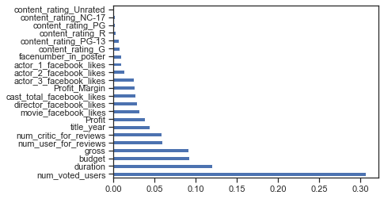

```python
pd.DataFrame(gb.feature_importances_, index = X.columns,
                                    columns=['importance']).sort_values('importance', ascending=False).plot(kind='barh',
                                                                                                            legend=None);
```

Takeaways

# 3. Clustering

## Import Data

```python
dfcu=pd.read_csv('data/imdbdatadf.csv')
dfcu.head()
```

|  | director_name | num_critic_for_reviews | duration | director_facebook_likes | actor_3_facebook_likes | actor_2_name | actor_1_facebook_likes | gross | genres | actor_1_name | movie_title | num_voted_users | cast_total_facebook_likes | actor_3_name | facenumber_in_poster | plot_keywords | num_user_for_reviews | country | content_rating | budget | title_year | actor_2_facebook_likes | imdb_score | movie_facebook_likes | Profit | Profit_Margin |
| --- | --- | --- | --- | --- | --- | --- | --- | --- | --- | --- | --- | --- | --- | --- | --- | --- | --- | --- | --- | --- | --- | --- | --- | --- | --- | --- |
| 0 | Ekachai Uekrongtham | 66 | 96 | 3 | 305 | Mike Dopud | 2000 | 162 | Action\|Crime\|Thriller | Michael Jai White | Skin Trade | 5228 | 2802 | Celina Jade | 5 | bangkok thailand\|detective\|human trafficking\|revenge\|sex slavery | 38 | Thailand | R | 9000000 | 2014 | 368 | 5.700 | 0 | -8999838 | -55554.560 |
| 1 | Chan-wook Park | 202 | 112 | 0 | 38 | Yeong-ae Lee | 717 | 211667 | Crime\|Drama | Min-sik Choi | Lady Vengeance | 53508 | 907 | Hye-jeong Kang | 0 | cake\|christian\|lesbian sex\|oral sex\|pregnant schoolgirl | 131 | South Korea | R | 4200000000 | 2005 | 126 | 7.700 | 4000 | -4199788333 | -19841.490 |
| 2 | Lajos Koltai | 73 | 134 | 45 | 0 | Péter Fancsikai | 9 | 195888 | Drama\|Romance\|War | Marcell Nagy | Fateless | 5603 | 11 | Bálint Péntek | 0 | bus\|death\|gay slur\|hatred\|jewish | 45 | Hungary | R | 2500000000 | 2005 | 2 | 7.100 | 607 | -2499804112 | -12761.390 |
| 3 | Yimou Zhang | 136 | 146 | 611 | 28 | Ni Ni | 23000 | 9213 | Drama\|History\|Romance\|War | Christian Bale | The Flowers of War | 38690 | 23240 | Shigeo Kobayashi | 2 | abusive stepfather\|attempted rape\|food shortage\|sexual abuse\|starving child | 130 | China | R | 94000000 | 2011 | 196 | 7.600 | 13000 | -93990787 | -10201.970 |
| 4 | Amy Heckerling | 54 | 92 | 143 | 613 | Justin Kirk | 1000 | 2964 | Comedy\|Horror\|Romance | Taylor Negron | Vamps | 7444 | 3086 | Ivan Sergei | 2 | murder\|new york city\|one word title\|vampire\|vampire slayer | 42 | USA | PG-13 | 16000000 | 2012 | 945 | 5.100 | 0 | -15997036 | -5397.110 |

```python
dfcu.info()
```

```
<class 'pandas.core.frame.DataFrame'>
RangeIndex: 3778 entries, 0 to 3777
Data columns (total 26 columns):
director_name                3778 non-null object
num_critic_for_reviews       3778 non-null int64
duration                     3778 non-null int64
director_facebook_likes      3778 non-null int64
actor_3_facebook_likes       3778 non-null int64
actor_2_name                 3778 non-null object
actor_1_facebook_likes       3778 non-null int64
gross                        3778 non-null int64
genres                       3778 non-null object
actor_1_name                 3778 non-null object
movie_title                  3778 non-null object
num_voted_users              3778 non-null int64
cast_total_facebook_likes    3778 non-null int64
actor_3_name                 3778 non-null object
facenumber_in_poster         3778 non-null int64
plot_keywords                3778 non-null object
num_user_for_reviews         3778 non-null int64
country                      3778 non-null object
content_rating               3778 non-null object
budget                       3778 non-null int64
title_year                   3778 non-null int64
actor_2_facebook_likes       3778 non-null int64
imdb_score                   3778 non-null float64
movie_facebook_likes         3778 non-null int64
Profit                       3778 non-null int64
Profit_Margin                3778 non-null float64
dtypes: float64(2), int64(15), object(9)
memory usage: 767.5+ KB
```

Identify Objects

## Data Editing

```python
dfclu = dfcu.drop(['director_name','actor_2_name','actor_1_name','movie_title','genres','actor_3_name','plot_keywords','country','content_rating'], axis =1)
dfclu.head()
```

|  | num_critic_for_reviews | duration | director_facebook_likes | actor_3_facebook_likes | actor_1_facebook_likes | gross | num_voted_users | cast_total_facebook_likes | facenumber_in_poster | num_user_for_reviews | budget | title_year | actor_2_facebook_likes | imdb_score | movie_facebook_likes | Profit | Profit_Margin |
| --- | --- | --- | --- | --- | --- | --- | --- | --- | --- | --- | --- | --- | --- | --- | --- | --- | --- |
| 0 | 66 | 96 | 3 | 305 | 2000 | 162 | 5228 | 2802 | 5 | 38 | 9000000 | 2014 | 368 | 5.700 | 0 | -8999838 | -55554.560 |
| 1 | 202 | 112 | 0 | 38 | 717 | 211667 | 53508 | 907 | 0 | 131 | 4200000000 | 2005 | 126 | 7.700 | 4000 | -4199788333 | -19841.490 |
| 2 | 73 | 134 | 45 | 0 | 9 | 195888 | 5603 | 11 | 0 | 45 | 2500000000 | 2005 | 2 | 7.100 | 607 | -2499804112 | -12761.390 |
| 3 | 136 | 146 | 611 | 28 | 23000 | 9213 | 38690 | 23240 | 2 | 130 | 94000000 | 2011 | 196 | 7.600 | 13000 | -93990787 | -10201.970 |
| 4 | 54 | 92 | 143 | 613 | 1000 | 2964 | 7444 | 3086 | 2 | 42 | 16000000 | 2012 | 945 | 5.100 | 0 | -15997036 | -5397.110 |

remove object variables

```python
dfclu.info()
```

```
<class 'pandas.core.frame.DataFrame'>
RangeIndex: 3778 entries, 0 to 3777
Data columns (total 17 columns):
num_critic_for_reviews       3778 non-null int64
duration                     3778 non-null int64
director_facebook_likes      3778 non-null int64
actor_3_facebook_likes       3778 non-null int64
actor_1_facebook_likes       3778 non-null int64
gross                        3778 non-null int64
num_voted_users              3778 non-null int64
cast_total_facebook_likes    3778 non-null int64
facenumber_in_poster         3778 non-null int64
num_user_for_reviews         3778 non-null int64
budget                       3778 non-null int64
title_year                   3778 non-null int64
actor_2_facebook_likes       3778 non-null int64
imdb_score                   3778 non-null float64
movie_facebook_likes         3778 non-null int64
Profit                       3778 non-null int64
Profit_Margin                3778 non-null float64
dtypes: float64(2), int64(15)
memory usage: 501.8 KB
```

## Normalize

```python
df_norm = (dfclu - dfclu.mean()) / (dfclu.std())
df_norm.head()
```

|  | num_critic_for_reviews | duration | director_facebook_likes | actor_3_facebook_likes | actor_1_facebook_likes | gross | num_voted_users | cast_total_facebook_likes | facenumber_in_poster | num_user_for_reviews | budget | title_year | actor_2_facebook_likes | imdb_score | movie_facebook_likes | Profit | Profit_Margin |
| --- | --- | --- | --- | --- | --- | --- | --- | --- | --- | --- | --- | --- | --- | --- | --- | --- | --- |
| 0 | -0.804 | -0.622 | -0.260 | -0.244 | -0.367 | -0.746 | -0.655 | -0.452 | 1.777 | -0.717 | -0.311 | 1.110 | -0.360 | -0.724 | -0.431 | -0.162 | -54.603 |
| 1 | 0.296 | 0.085 | -0.261 | -0.388 | -0.450 | -0.743 | -0.336 | -0.552 | -0.673 | -0.491 | 38.659 | 0.200 | -0.414 | 1.175 | -0.244 | -36.981 | -19.471 |
| 2 | -0.748 | 1.057 | -0.247 | -0.408 | -0.495 | -0.743 | -0.653 | -0.599 | -0.673 | -0.700 | 22.851 | 0.200 | -0.441 | 0.605 | -0.403 | -22.045 | -12.506 |
| 3 | -0.238 | 1.586 | -0.061 | -0.393 | 0.987 | -0.745 | -0.434 | 0.621 | 0.307 | -0.493 | 0.479 | 0.807 | -0.398 | 1.080 | 0.175 | -0.909 | -9.989 |
| 4 | -0.901 | -0.798 | -0.215 | -0.078 | -0.431 | -0.746 | -0.641 | -0.437 | 0.307 | -0.708 | -0.246 | 0.908 | -0.232 | -1.293 | -0.431 | -0.223 | -5.262 |

## Elbow Method

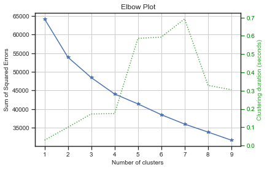

```python
import scikitplot as skplt

kmeans = KMeans(random_state=1)
skplt.cluster.plot_elbow_curve(kmeans, df_norm, cluster_ranges=range(1, 10))
```

Choose 2 3 or 4 clusters

## K-means

```python
df_norm.var()
```

```
num_critic_for_reviews      1.000
duration                    1.000
director_facebook_likes     1.000
actor_3_facebook_likes      1.000
actor_1_facebook_likes      1.000
gross                       1.000
num_voted_users             1.000
cast_total_facebook_likes   1.000
facenumber_in_poster        1.000
num_user_for_reviews        1.000
budget                      1.000
title_year                  1.000
actor_2_facebook_likes      1.000
imdb_score                  1.000
movie_facebook_likes        1.000
Profit                      1.000
Profit_Margin               1.000
dtype: float64
```

```python
k_means = KMeans(init='k-means++', n_clusters=4, random_state=0)
```

4 cluster k means

```python
k_means.fit(df_norm)
```

```
KMeans(algorithm='auto', copy_x=True, init='k-means++', max_iter=300,
       n_clusters=4, n_init=10, n_jobs=None, precompute_distances='auto',
       random_state=0, tol=0.0001, verbose=0)
```

```python
k_means.labels_
```

```
array([2, 2, 2, ..., 1, 0, 1])
```

```python
k_means.cluster_centers_
```

```
array([[-3.09990871e-01, -1.61655882e-01, -1.25848662e-01,
        -1.72932640e-01, -1.21426615e-01, -2.58688265e-01,
        -3.31544811e-01, -1.64475553e-01,  1.69646042e-03,
        -2.89723725e-01, -1.06009025e-01, -6.98122598e-02,
        -1.68516637e-01, -1.82897813e-01, -2.64644299e-01,
        -5.81386929e-02,  1.98611647e-02],
       [ 1.38726697e+00,  7.39858886e-01,  5.54781294e-01,
        -3.43180023e-02,  2.75714726e-01,  1.11075749e+00,
         1.51237968e+00,  2.96130682e-01, -1.15723392e-01,
         1.34169879e+00,  2.96040931e-01,  2.54381101e-01,
         2.95710045e-01,  8.78292973e-01,  1.16577851e+00,
         4.00000218e-01,  4.43720432e-02],
       [-3.35195513e-01,  2.52832905e-01,  1.39614174e-01,
        -2.80363406e-01, -4.42850834e-01, -7.36626109e-01,
        -2.93461297e-01, -5.21351157e-01, -8.53937809e-02,
        -3.89043194e-01,  2.05016156e+01,  2.00192720e-01,
        -3.66990438e-01,  6.62191205e-01, -2.76268776e-01,
        -1.98216129e+01, -1.85222517e+01],
       [ 1.07734462e+00,  4.51675331e-01,  4.71126811e-01,
         5.06164782e+00,  1.91228830e+00,  1.17871590e+00,
         9.91274080e-01,  3.01303517e+00,  5.94316232e-01,
         7.61541385e-01,  4.06210690e-01,  5.50008684e-01,
         3.12183188e+00,  2.66522636e-01,  1.02159586e+00,
         3.37493120e-01,  4.68707638e-02]])
```

place clusters into data frame

```python
df2 = dfclu.copy()
df2["cluster"]=k_means.labels_
df2.head()
```

|  | num_critic_for_reviews | duration | director_facebook_likes | actor_3_facebook_likes | actor_1_facebook_likes | gross | num_voted_users | cast_total_facebook_likes | facenumber_in_poster | num_user_for_reviews | budget | title_year | actor_2_facebook_likes | imdb_score | movie_facebook_likes | Profit | Profit_Margin | cluster |
| --- | --- | --- | --- | --- | --- | --- | --- | --- | --- | --- | --- | --- | --- | --- | --- | --- | --- | --- |
| 0 | 66 | 96 | 3 | 305 | 2000 | 162 | 5228 | 2802 | 5 | 38 | 9000000 | 2014 | 368 | 5.700 | 0 | -8999838 | -55554.560 | 2 |
| 1 | 202 | 112 | 0 | 38 | 717 | 211667 | 53508 | 907 | 0 | 131 | 4200000000 | 2005 | 126 | 7.700 | 4000 | -4199788333 | -19841.490 | 2 |
| 2 | 73 | 134 | 45 | 0 | 9 | 195888 | 5603 | 11 | 0 | 45 | 2500000000 | 2005 | 2 | 7.100 | 607 | -2499804112 | -12761.390 | 2 |
| 3 | 136 | 146 | 611 | 28 | 23000 | 9213 | 38690 | 23240 | 2 | 130 | 94000000 | 2011 | 196 | 7.600 | 13000 | -93990787 | -10201.970 | 0 |
| 4 | 54 | 92 | 143 | 613 | 1000 | 2964 | 7444 | 3086 | 2 | 42 | 16000000 | 2012 | 945 | 5.100 | 0 | -15997036 | -5397.110 | 0 |

```python
df2.tail()
```

|  | num_critic_for_reviews | duration | director_facebook_likes | actor_3_facebook_likes | actor_1_facebook_likes | gross | num_voted_users | cast_total_facebook_likes | facenumber_in_poster | num_user_for_reviews | budget | title_year | actor_2_facebook_likes | imdb_score | movie_facebook_likes | Profit | Profit_Margin | cluster |
| --- | --- | --- | --- | --- | --- | --- | --- | --- | --- | --- | --- | --- | --- | --- | --- | --- | --- | --- |
| 3773 | 277 | 88 | 365 | 177 | 383 | 30859000 | 96411 | 1094 | 0 | 826 | 83532 | 1974 | 371 | 7.500 | 0 | 30775468 | 1.000 | 0 |
| 3774 | 36 | 98 | 0 | 73 | 138 | 10246600 | 6375 | 388 | 0 | 36 | 25000 | 1995 | 111 | 6.600 | 265 | 10221600 | 1.000 | 0 |
| 3775 | 360 | 81 | 19 | 39 | 170 | 140530114 | 186786 | 399 | 0 | 3400 | 60000 | 1999 | 170 | 6.400 | 0 | 140470114 | 1.000 | 1 |
| 3776 | 72 | 88 | 20 | 0 | 58 | 592014 | 5709 | 78 | 3 | 114 | 218 | 2003 | 20 | 7.200 | 754 | 591796 | 1.000 | 0 |
| 3777 | 409 | 84 | 110 | 21 | 189 | 107917283 | 184824 | 330 | 0 | 1189 | 15000 | 2007 | 109 | 6.300 | 12000 | 107902283 | 1.000 | 1 |

Pivot Table averages into cluster segments

```python
df2.groupby(['cluster']).mean()
```

| cluster | num_critic_for_reviews | duration | director_facebook_likes | actor_3_facebook_likes | actor_1_facebook_likes | gross | num_voted_users | cast_total_facebook_likes | facenumber_in_poster | num_user_for_reviews | budget | title_year | actor_2_facebook_likes | imdb_score | movie_facebook_likes | Profit | Profit_Margin |
| --- | --- | --- | --- | --- | --- | --- | --- | --- | --- | --- | --- | --- | --- | --- | --- | --- | --- |
| 0 | 127.116 | 106.414 | 414.063 | 437.226 | 5806.555 | 33912174.625 | 54166.495 | 8278.981 | 1.378 | 213.311 | 31096891.454 | 2002.330 | 1231.030 | 6.270 | 3565.345 | 2815283.171 | -27.885 |
| 1 | 336.960 | 126.829 | 2493.767 | 694.539 | 11966.052 | 129295631.960 | 332913.546 | 17048.755 | 1.138 | 882.038 | 74334575.403 | 2005.536 | 3323.085 | 7.388 | 34247.920 | 54961056.557 | -2.968 |
| 2 | 124.000 | 115.800 | 1225.200 | 237.800 | 821.400 | 623259.200 | 59923.600 | 1484.200 | 1.200 | 172.600 | 2247303979.600 | 2005.000 | 336.600 | 7.160 | 3316.000 | -2246680720.400 | -18876.782 |
| 3 | 298.642 | 120.303 | 2238.156 | 10154.284 | 37348.624 | 134029012.560 | 254137.734 | 68777.624 | 2.587 | 644.229 | 86182568.807 | 2008.459 | 16059.110 | 6.743 | 31155.202 | 47846443.752 | -0.428 |

Pivot Table counts into cluster segments

```python
df2.groupby('cluster').size()
```

```
cluster
0    3063
1    601
2    5
3    109
dtype: int64
```

Visualize clusters

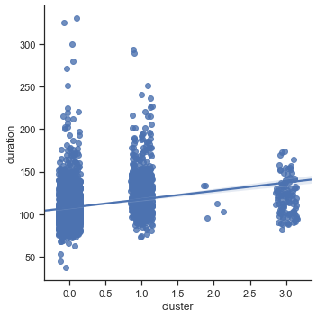

```python
sns.lmplot("cluster", "duration", df2, x_jitter=.15, y_jitter=.15)
```

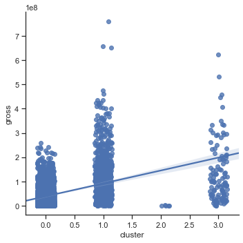

```python
sns.lmplot("cluster", "gross", df2, x_jitter=.15, y_jitter=.15)
```

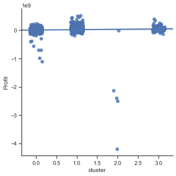

```python
sns.lmplot("cluster", "Profit", df2, x_jitter=.15, y_jitter=.15)
```

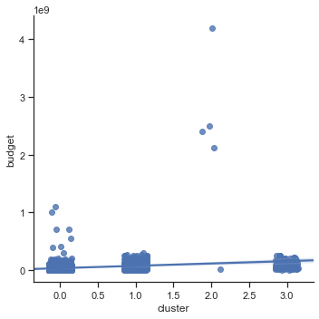

```python
sns.lmplot("cluster", "budget", df2, x_jitter=.15, y_jitter=.15)
```

```python
df2.to_csv("data/imdbdataKMeansData.csv")
```

## Hierarchical Clustering (3 Clusters)

```python
X = df_norm
```

make normalized data as X

graph to determine how many clusters to choose

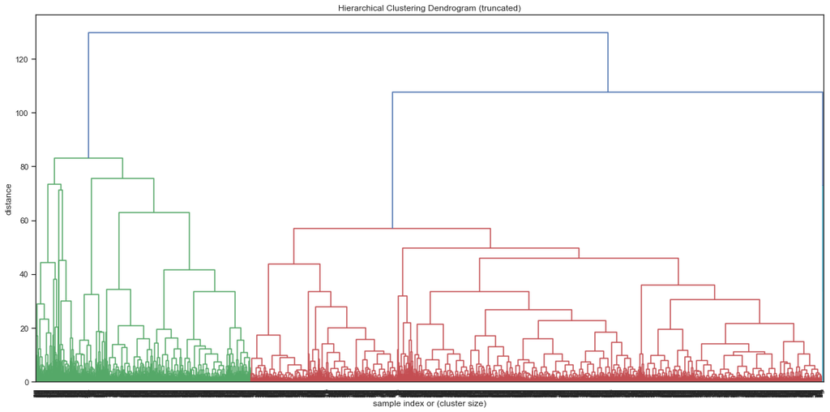

```python
plt.figure(figsize=(16,8))

plt.title('Hierarchical Clustering Dendrogram (truncated)')
plt.xlabel('sample index or (cluster size)')
plt.ylabel('distance')


linkage_matrix = ward(X)
dendrogram(linkage_matrix, orientation="top")
plt.tight_layout() # fixes margins
```

```python
np.random.seed(1) # setting random seed to get the same results each time.



agg= AgglomerativeClustering(n_clusters=3, linkage='ward').fit(X)
agg.labels_
```

```
array([1, 1, 1, ..., 0, 2, 0], dtype=int64)
```

Add clusters into data frame

```python
df3 = dfclu.copy()
df3["cluster"]=agg.labels_
df3.head()
```

|  | num_critic_for_reviews | duration | director_facebook_likes | actor_3_facebook_likes | actor_1_facebook_likes | gross | num_voted_users | cast_total_facebook_likes | facenumber_in_poster | num_user_for_reviews | budget | title_year | actor_2_facebook_likes | imdb_score | movie_facebook_likes | Profit | Profit_Margin | cluster |
| --- | --- | --- | --- | --- | --- | --- | --- | --- | --- | --- | --- | --- | --- | --- | --- | --- | --- | --- |
| 0 | 66 | 96 | 3 | 305 | 2000 | 162 | 5228 | 2802 | 5 | 38 | 9000000 | 2014 | 368 | 5.700 | 0 | -8999838 | -55554.560 | 1 |
| 1 | 202 | 112 | 0 | 38 | 717 | 211667 | 53508 | 907 | 0 | 131 | 4200000000 | 2005 | 126 | 7.700 | 4000 | -4199788333 | -19841.490 | 1 |
| 2 | 73 | 134 | 45 | 0 | 9 | 195888 | 5603 | 11 | 0 | 45 | 2500000000 | 2005 | 2 | 7.100 | 607 | -2499804112 | -12761.390 | 1 |
| 3 | 136 | 146 | 611 | 28 | 23000 | 9213 | 38690 | 23240 | 2 | 130 | 94000000 | 2011 | 196 | 7.600 | 13000 | -93990787 | -10201.970 | 2 |
| 4 | 54 | 92 | 143 | 613 | 1000 | 2964 | 7444 | 3086 | 2 | 42 | 16000000 | 2012 | 945 | 5.100 | 0 | -15997036 | -5397.110 | 2 |

```python
df3.groupby(['cluster']).mean().T
```

| cluster | 0 | 1 | 2 |
| --- | --- | --- | --- |
| num_critic_for_reviews | 286.483 | 124.000 | 119.946 |
| duration | 118.671 | 115.800 | 106.828 |
| director_facebook_likes | 2541.251 | 1225.200 | 141.706 |
| actor_3_facebook_likes | 1699.672 | 237.800 | 404.742 |
| actor_1_facebook_likes | 14829.345 | 821.400 | 5014.298 |
| gross | 98677991.728 | 623259.200 | 34422889.672 |
| num_voted_users | 240572.871 | 59923.600 | 53054.661 |
| cast_total_facebook_likes | 23492.451 | 1484.200 | 6879.742 |
| facenumber_in_poster | 1.371 | 1.200 | 1.376 |
| num_user_for_reviews | 650.473 | 172.600 | 212.481 |
| budget | 63465400.636 | 2247303979.600 | 30580979.528 |
| title_year | 2006.202 | 2005.000 | 2001.819 |
| actor_2_facebook_likes | 5451.067 | 336.600 | 690.536 |
| imdb_score | 7.033 | 7.160 | 6.246 |
| movie_facebook_likes | 27195.828 | 3316.000 | 2493.059 |
| Profit | 35212591.092 | -2246680720.400 | 3841910.144 |
| Profit_Margin | -7.093 | -18876.782 | -29.158 |

```python
df3.groupby('cluster').size()
```

```
cluster
0    1032
1    5
2    2741
dtype: int64
```

```python
df3[df3['cluster'] == 1]
```

|  | num_critic_for_reviews | duration | director_facebook_likes | actor_3_facebook_likes | actor_1_facebook_likes | gross | num_voted_users | cast_total_facebook_likes | facenumber_in_poster | num_user_for_reviews | budget | title_year | actor_2_facebook_likes | imdb_score | movie_facebook_likes | Profit | Profit_Margin | cluster |
| --- | --- | --- | --- | --- | --- | --- | --- | --- | --- | --- | --- | --- | --- | --- | --- | --- | --- | --- |
| 0 | 66 | 96 | 3 | 305 | 2000 | 162 | 5228 | 2802 | 5 | 38 | 9000000 | 2014 | 368 | 5.700 | 0 | -8999838 | -55554.560 | 1 |
| 1 | 202 | 112 | 0 | 38 | 717 | 211667 | 53508 | 907 | 0 | 131 | 4200000000 | 2005 | 126 | 7.700 | 4000 | -4199788333 | -19841.490 | 1 |
| 2 | 73 | 134 | 45 | 0 | 9 | 195888 | 5603 | 11 | 0 | 45 | 2500000000 | 2005 | 2 | 7.100 | 607 | -2499804112 | -12761.390 | 1 |
| 6 | 105 | 103 | 78 | 101 | 488 | 410388 | 13727 | 991 | 1 | 79 | 2127519898 | 2004 | 336 | 6.900 | 973 | -2127109510 | -5183.170 | 1 |
| 22 | 174 | 134 | 6000 | 745 | 893 | 2298191 | 221552 | 2710 | 0 | 570 | 2400000000 | 1997 | 851 | 8.400 | 11000 | -2397701809 | -1043.300 | 1 |

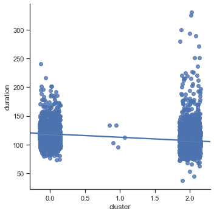

```python
sns.lmplot("cluster", "duration", df3, x_jitter=.15, y_jitter=.15)
```

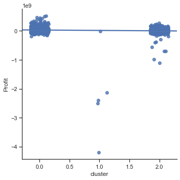

```python
sns.lmplot("cluster", "Profit", df3, x_jitter=.15, y_jitter=.15)
```

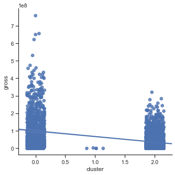

```python
sns.lmplot("cluster", "gross", df3, x_jitter=.15, y_jitter=.15)
```

```python
df3.to_csv("data/imdbdataHierClusData.csv")
```

## Hierarchical Clustering (2 Clusters) Removed Outliers.

```python
dfcu=pd.read_csv('data/imdbdatadfc2.csv')
dfcu.head()
```

|  | director_name | num_critic_for_reviews | duration | director_facebook_likes | actor_3_facebook_likes | actor_2_name | actor_1_facebook_likes | gross | genres | actor_1_name | movie_title | num_voted_users | cast_total_facebook_likes | actor_3_name | facenumber_in_poster | plot_keywords | num_user_for_reviews | country | content_rating | budget | title_year | actor_2_facebook_likes | imdb_score | movie_facebook_likes | Profit | Profit_Margin |
| --- | --- | --- | --- | --- | --- | --- | --- | --- | --- | --- | --- | --- | --- | --- | --- | --- | --- | --- | --- | --- | --- | --- | --- | --- | --- | --- |
| 0 | Yimou Zhang | 136 | 146 | 611 | 28 | Ni Ni | 23000 | 9213 | Drama\|History\|Romance\|War | Christian Bale | The Flowers of War | 38690 | 23240 | Shigeo Kobayashi | 2 | abusive stepfather\|attempted rape\|food shortage\|sexual abuse\|starving child | 130 | China | R | 94000000 | 2011 | 196 | 7.600 | 13000 | -93990787 | -10201.970 |
| 1 | Amy Heckerling | 54 | 92 | 143 | 613 | Justin Kirk | 1000 | 2964 | Comedy\|Horror\|Romance | Taylor Negron | Vamps | 7444 | 3086 | Ivan Sergei | 2 | murder\|new york city\|one word title\|vampire\|vampire slayer | 42 | USA | PG-13 | 16000000 | 2012 | 945 | 5.100 | 0 | -15997036 | -5397.110 |
| 2 | Jonathan Newman | 28 | 100 | 3 | 88 | Keeley Hawes | 2000 | 4756 | Adventure\|Family\|Fantasy | Ioan Gruffudd | The Adventurer: The Curse of the Midas Box | 4191 | 2450 | Oliver Stark | 4 | based on novel\|drowning\|hanging from a flagpole\|hanging from a rope\|magic | 32 | UK | PG | 25000000 | 2013 | 228 | 5.400 | 0 | -24995244 | -5255.520 |
| 3 | Tony Scott | 142 | 114 | 12000 | 307 | Stephen Dillane | 11000 | 26871 | Action\|Crime\|Thriller | Brad Pitt | Spy Game | 121259 | 12499 | Catherine McCormack | 2 | china\|cia\|cold war\|friendship\|retirement | 361 | Germany | R | 92000000 | 2001 | 577 | 7.000 | 0 | -91973129 | -3422.770 |
| 4 | Tony Jaa | 110 | 110 | 0 | 7 | Petchtai Wongkamlao | 64 | 102055 | Action | Nirut Sirichanya | Ong-bak 2 | 24570 | 134 | Sarunyu Wongkrachang | 0 | cult film\|elephant\|jungle\|martial arts\|stylized violence | 72 | Thailand | R | 300000000 | 2008 | 45 | 6.200 | 0 | -299897945 | -2938.590 |

```python
dfclu = dfcu.drop(['director_name','actor_2_name','actor_1_name','movie_title','genres','actor_3_name','plot_keywords','country','content_rating'], axis =1)
dfclu.head()
```

|  | num_critic_for_reviews | duration | director_facebook_likes | actor_3_facebook_likes | actor_1_facebook_likes | gross | num_voted_users | cast_total_facebook_likes | facenumber_in_poster | num_user_for_reviews | budget | title_year | actor_2_facebook_likes | imdb_score | movie_facebook_likes | Profit | Profit_Margin |
| --- | --- | --- | --- | --- | --- | --- | --- | --- | --- | --- | --- | --- | --- | --- | --- | --- | --- |
| 0 | 136 | 146 | 611 | 28 | 23000 | 9213 | 38690 | 23240 | 2 | 130 | 94000000 | 2011 | 196 | 7.600 | 13000 | -93990787 | -10201.970 |
| 1 | 54 | 92 | 143 | 613 | 1000 | 2964 | 7444 | 3086 | 2 | 42 | 16000000 | 2012 | 945 | 5.100 | 0 | -15997036 | -5397.110 |
| 2 | 28 | 100 | 3 | 88 | 2000 | 4756 | 4191 | 2450 | 4 | 32 | 25000000 | 2013 | 228 | 5.400 | 0 | -24995244 | -5255.520 |
| 3 | 142 | 114 | 12000 | 307 | 11000 | 26871 | 121259 | 12499 | 2 | 361 | 92000000 | 2001 | 577 | 7.000 | 0 | -91973129 | -3422.770 |
| 4 | 110 | 110 | 0 | 7 | 64 | 102055 | 24570 | 134 | 0 | 72 | 300000000 | 2008 | 45 | 6.200 | 0 | -299897945 | -2938.590 |

```python
df4 = df3.copy()
df4 = df4[df4['cluster']!= 1 ].copy()
df4 = ((df4-df4.mean()) / df4.std())
df4.drop('cluster',axis=1,inplace=True)
X = df4.copy()
```

Dropped Cluster one from above data frame

```python
np.random.seed(1) # setting random seed to get the same results each time.



agg= AgglomerativeClustering(n_clusters=2, linkage='ward').fit(X)
agg.labels_
```

```
array([1, 1, 1, ..., 0, 1, 0], dtype=int64)
```

```python
df5 = dfclu.copy()
df5["cluster"]=agg.labels_
df5.head()
```

|  | num_critic_for_reviews | duration | director_facebook_likes | actor_3_facebook_likes | actor_1_facebook_likes | gross | num_voted_users | cast_total_facebook_likes | facenumber_in_poster | num_user_for_reviews | budget | title_year | actor_2_facebook_likes | imdb_score | movie_facebook_likes | Profit | Profit_Margin | cluster |
| --- | --- | --- | --- | --- | --- | --- | --- | --- | --- | --- | --- | --- | --- | --- | --- | --- | --- | --- |
| 0 | 136 | 146 | 611 | 28 | 23000 | 9213 | 38690 | 23240 | 2 | 130 | 94000000 | 2011 | 196 | 7.600 | 13000 | -93990787 | -10201.970 | 1 |
| 1 | 54 | 92 | 143 | 613 | 1000 | 2964 | 7444 | 3086 | 2 | 42 | 16000000 | 2012 | 945 | 5.100 | 0 | -15997036 | -5397.110 | 1 |
| 2 | 28 | 100 | 3 | 88 | 2000 | 4756 | 4191 | 2450 | 4 | 32 | 25000000 | 2013 | 228 | 5.400 | 0 | -24995244 | -5255.520 | 1 |
| 3 | 142 | 114 | 12000 | 307 | 11000 | 26871 | 121259 | 12499 | 2 | 361 | 92000000 | 2001 | 577 | 7.000 | 0 | -91973129 | -3422.770 | 1 |
| 4 | 110 | 110 | 0 | 7 | 64 | 102055 | 24570 | 134 | 0 | 72 | 300000000 | 2008 | 45 | 6.200 | 0 | -299897945 | -2938.590 | 1 |

Added cluster into df

```python
df5.groupby(['cluster']).mean().T
```

| cluster | 0 | 1 |
| --- | --- | --- |
| num_critic_for_reviews | 280.203 | 123.794 |
| duration | 117.467 | 107.377 |
| director_facebook_likes | 2587.767 | 147.342 |
| actor_3_facebook_likes | 1725.465 | 407.532 |
| actor_1_facebook_likes | 14508.526 | 5223.166 |
| gross | 101129600.674 | 34135326.988 |
| num_voted_users | 245897.349 | 52880.844 |
| cast_total_facebook_likes | 23276.721 | 7114.276 |
| facenumber_in_poster | 1.332 | 1.390 |
| num_user_for_reviews | 675.084 | 207.649 |
| budget | 60006578.982 | 32147502.669 |
| title_year | 2005.234 | 2002.213 |
| actor_2_facebook_likes | 5504.530 | 715.831 |
| imdb_score | 7.090 | 6.233 |
| movie_facebook_likes | 25473.255 | 3351.454 |
| Profit | 41123021.692 | 1987824.319 |
| Profit_Margin | -3.422 | -30.285 |

```python
df5.groupby('cluster').size()
```

```
cluster
0    1006
1    2767
dtype: int64
```

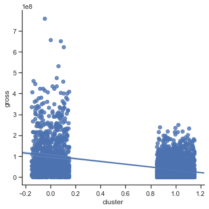

```python
sns.lmplot("cluster", "gross", df5, x_jitter=.15, y_jitter=.15)
```

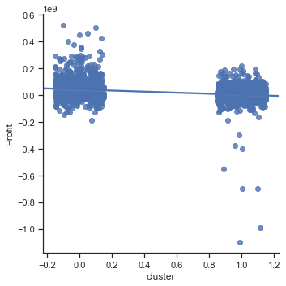

```python
sns.lmplot("cluster", "Profit", df5, x_jitter=.15, y_jitter=.15)
```

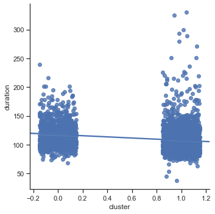

```python
sns.lmplot("cluster", "duration", df5, x_jitter=.15, y_jitter=.15)
```

df4.to_csv("data/imdbdataHierClusData.csv")

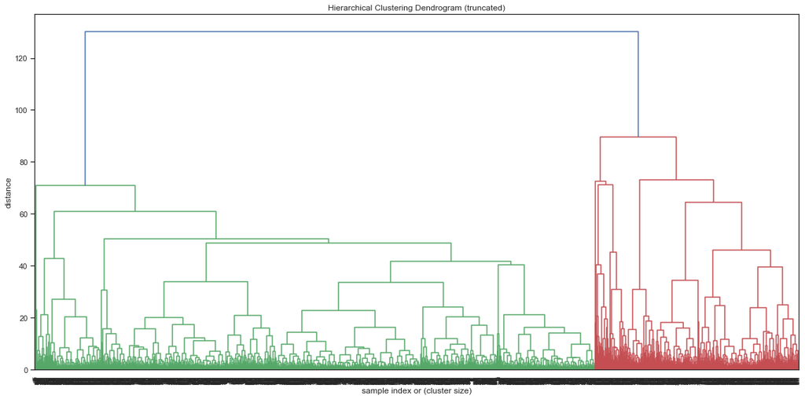

```python
plt.figure(figsize=(16,8))

plt.title('Hierarchical Clustering Dendrogram (truncated)')
plt.xlabel('sample index or (cluster size)')
plt.ylabel('distance')


linkage_matrix = ward(X)
dendrogram(linkage_matrix, orientation="top")
plt.tight_layout() # fixes margins
```

## Clustering Analysis

### K-Means

```python
df2.groupby('cluster').size()
```

```
cluster
0    3063
1    601
2    5
3    109
dtype: int64
```

```python
df2.groupby(['cluster']).mean()
```

| cluster | num_critic_for_reviews | duration | director_facebook_likes | actor_3_facebook_likes | actor_1_facebook_likes | gross | num_voted_users | cast_total_facebook_likes | facenumber_in_poster | num_user_for_reviews | budget | title_year | actor_2_facebook_likes | imdb_score | movie_facebook_likes | Profit | Profit_Margin |
| --- | --- | --- | --- | --- | --- | --- | --- | --- | --- | --- | --- | --- | --- | --- | --- | --- | --- |
| 0 | 127.116 | 106.414 | 414.063 | 437.226 | 5806.555 | 33912174.625 | 54166.495 | 8278.981 | 1.378 | 213.311 | 31096891.454 | 2002.330 | 1231.030 | 6.270 | 3565.345 | 2815283.171 | -27.885 |
| 1 | 336.960 | 126.829 | 2493.767 | 694.539 | 11966.052 | 129295631.960 | 332913.546 | 17048.755 | 1.138 | 882.038 | 74334575.403 | 2005.536 | 3323.085 | 7.388 | 34247.920 | 54961056.557 | -2.968 |
| 2 | 124.000 | 115.800 | 1225.200 | 237.800 | 821.400 | 623259.200 | 59923.600 | 1484.200 | 1.200 | 172.600 | 2247303979.600 | 2005.000 | 336.600 | 7.160 | 3316.000 | -2246680720.400 | -18876.782 |
| 3 | 298.642 | 120.303 | 2238.156 | 10154.284 | 37348.624 | 134029012.560 | 254137.734 | 68777.624 | 2.587 | 644.229 | 86182568.807 | 2008.459 | 16059.110 | 6.743 | 31155.202 | 47846443.752 | -0.428 |

### Hierarchical 1

```python
df3.groupby('cluster').size()
```

```
cluster
0    1032
1    5
2    2741
dtype: int64
```

```python
df3.groupby(['cluster']).mean()
```

| cluster | num_critic_for_reviews | duration | director_facebook_likes | actor_3_facebook_likes | actor_1_facebook_likes | gross | num_voted_users | cast_total_facebook_likes | facenumber_in_poster | num_user_for_reviews | budget | title_year | actor_2_facebook_likes | imdb_score | movie_facebook_likes | Profit | Profit_Margin |
| --- | --- | --- | --- | --- | --- | --- | --- | --- | --- | --- | --- | --- | --- | --- | --- | --- | --- |
| 0 | 286.483 | 118.671 | 2541.251 | 1699.672 | 14829.345 | 98677991.728 | 240572.871 | 23492.451 | 1.371 | 650.473 | 63465400.636 | 2006.202 | 5451.067 | 7.033 | 27195.828 | 35212591.092 | -7.093 |
| 1 | 124.000 | 115.800 | 1225.200 | 237.800 | 821.400 | 623259.200 | 59923.600 | 1484.200 | 1.200 | 172.600 | 2247303979.600 | 2005.000 | 336.600 | 7.160 | 3316.000 | -2246680720.400 | -18876.782 |
| 2 | 119.946 | 106.828 | 141.706 | 404.742 | 5014.298 | 34422889.672 | 53054.661 | 6879.742 | 1.376 | 212.481 | 30580979.528 | 2001.819 | 690.536 | 6.246 | 2493.059 | 3841910.144 | -29.158 |

### Hierarchical 2

```python
df5.groupby('cluster').size()
```

```
cluster
0    1006
1    2767
dtype: int64
```

```python
df5.groupby(['cluster']).mean()
```

| cluster | num_critic_for_reviews | duration | director_facebook_likes | actor_3_facebook_likes | actor_1_facebook_likes | gross | num_voted_users | cast_total_facebook_likes | facenumber_in_poster | num_user_for_reviews | budget | title_year | actor_2_facebook_likes | imdb_score | movie_facebook_likes | Profit | Profit_Margin |
| --- | --- | --- | --- | --- | --- | --- | --- | --- | --- | --- | --- | --- | --- | --- | --- | --- | --- |
| 0 | 280.203 | 117.467 | 2587.767 | 1725.465 | 14508.526 | 101129600.674 | 245897.349 | 23276.721 | 1.332 | 675.084 | 60006578.982 | 2005.234 | 5504.530 | 7.090 | 25473.255 | 41123021.692 | -3.422 |
| 1 | 123.794 | 107.377 | 147.342 | 407.532 | 5223.166 | 34135326.988 | 52880.844 | 7114.276 | 1.390 | 207.649 | 32147502.669 | 2002.213 | 715.831 | 6.233 | 3351.454 | 1987824.319 | -30.285 |

# Storytelling

## Regression

Takeaways

- Random Forest Regressor is the best regression model to use with this dataframe
  - R Score: .938
  - Most Important Features: number of voted users/duration/budget/gross

## Clustering

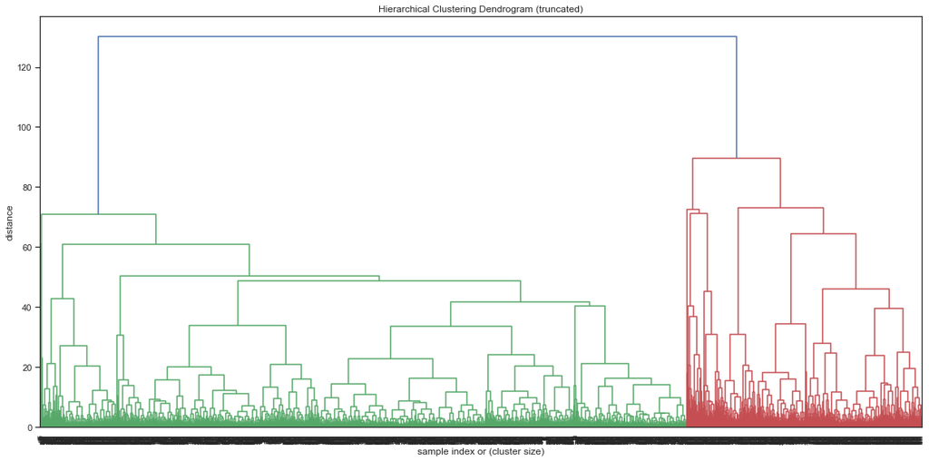

```python
plt.figure(figsize=(16,8))

plt.title('Hierarchical Clustering Dendrogram (truncated)')
plt.xlabel('sample index or (cluster size)')
plt.ylabel('distance')


linkage_matrix = ward(X)
dendrogram(linkage_matrix, orientation="top")
plt.tight_layout() # fixes margins
```

```python
df5.groupby(['cluster']).mean()
```

| cluster | num_critic_for_reviews | duration | director_facebook_likes | actor_3_facebook_likes | actor_1_facebook_likes | gross | num_voted_users | cast_total_facebook_likes | facenumber_in_poster | num_user_for_reviews | budget | title_year | actor_2_facebook_likes | imdb_score | movie_facebook_likes | Profit | Profit_Margin |
| --- | --- | --- | --- | --- | --- | --- | --- | --- | --- | --- | --- | --- | --- | --- | --- | --- | --- |
| 0 | 280.203 | 117.467 | 2587.767 | 1725.465 | 14508.526 | 101129600.674 | 245897.349 | 23276.721 | 1.332 | 675.084 | 60006578.982 | 2005.234 | 5504.530 | 7.090 | 25473.255 | 41123021.692 | -3.422 |
| 1 | 123.794 | 107.377 | 147.342 | 407.532 | 5223.166 | 34135326.988 | 52880.844 | 7114.276 | 1.390 | 207.649 | 32147502.669 | 2002.213 | 715.831 | 6.233 | 3351.454 | 1987824.319 | -30.285 |

There are two main clusters

- Cluster 0 are these factors over Cluster 1
  - movies that scored higher IMDB scores
  - Longer duration
  - Higher budget
  - More critic reviews
  - More likes in all variables
  - Grossed more money
  - Less faces in posters
  - Newer Movies
  - Better profit margins

### Additional Storytelling

The most important variables in the IMDB data set are:

- num_critic_for_reviews'
- 'gross'
- 'num_user_for_reviews'
- 'budget'
- 'duration'
- 'num_voted_users'

My advice for business people in the movie industry is to get has many critics to review your movie, shoot for a large gross, presuaded users to review the movie, have a massive budget, make the movie longer, and get voted useres to review as well.

Other Variables I would need to predict better would be

- what time of the year did this movie come out
- is this a sequal or a stand alone movie
- what production company made the movie

conda install -c conda-forge rise

```python
pip install RISE
```